# Resolução do Exame Final

Análise Multivariada

Autor

Prof. Dr. Washington S. da Silva

Data de Publicação

5 de dezembro de 2023

## Questão 1

### 1.1

```r
# define o caminho do arquivo
path_xls <- here::here("data_raw", "fred.xls")

# importa o arquivo
taxas_juros <- readxl::read_xls(path_xls)

# visao geral da estrutura dos dados
dplyr::glimpse(taxas_juros)
```

```
Rows: 437
Columns: 7
$ Date <dttm> 1982-01-01, 1982-02-01, 1982-03-01, 1982-04-01, 1982-05-01, 1982…
$ GS3  <dbl> 14.64, 14.73, 14.13, 14.18, 13.77, 14.48, 14.00, 12.62, 12.03, 10…
$ GS1  <dbl> 14.32, 14.73, 13.95, 13.98, 13.34, 14.07, 13.24, 11.43, 10.85, 9.…
$ GS10 <dbl> 14.59, 14.43, 13.86, 13.87, 13.62, 14.30, 13.95, 13.06, 12.34, 10…
$ GS5  <dbl> 14.65, 14.54, 13.98, 14.00, 13.75, 14.43, 14.07, 13.00, 12.25, 10…
$ GS3M <dbl> 12.92, 14.28, 13.31, 13.34, 12.71, 13.08, 11.86, 9.00, 8.19, 7.97…
$ GS6M <dbl> 13.90, 14.81, 13.83, 13.87, 13.13, 13.76, 12.80, 10.51, 9.83, 8.6…
```

```r
# elimine a primeira coluna de series_juros
taxas_juros <- taxas_juros[,-1]
dplyr::glimpse(taxas_juros)
```

```
Rows: 437
Columns: 6
$ GS3  <dbl> 14.64, 14.73, 14.13, 14.18, 13.77, 14.48, 14.00, 12.62, 12.03, 10…
$ GS1  <dbl> 14.32, 14.73, 13.95, 13.98, 13.34, 14.07, 13.24, 11.43, 10.85, 9.…
$ GS10 <dbl> 14.59, 14.43, 13.86, 13.87, 13.62, 14.30, 13.95, 13.06, 12.34, 10…
$ GS5  <dbl> 14.65, 14.54, 13.98, 14.00, 13.75, 14.43, 14.07, 13.00, 12.25, 10…
$ GS3M <dbl> 12.92, 14.28, 13.31, 13.34, 12.71, 13.08, 11.86, 9.00, 8.19, 7.97…
$ GS6M <dbl> 13.90, 14.81, 13.83, 13.87, 13.13, 13.76, 12.80, 10.51, 9.83, 8.6…
```

### 1.2

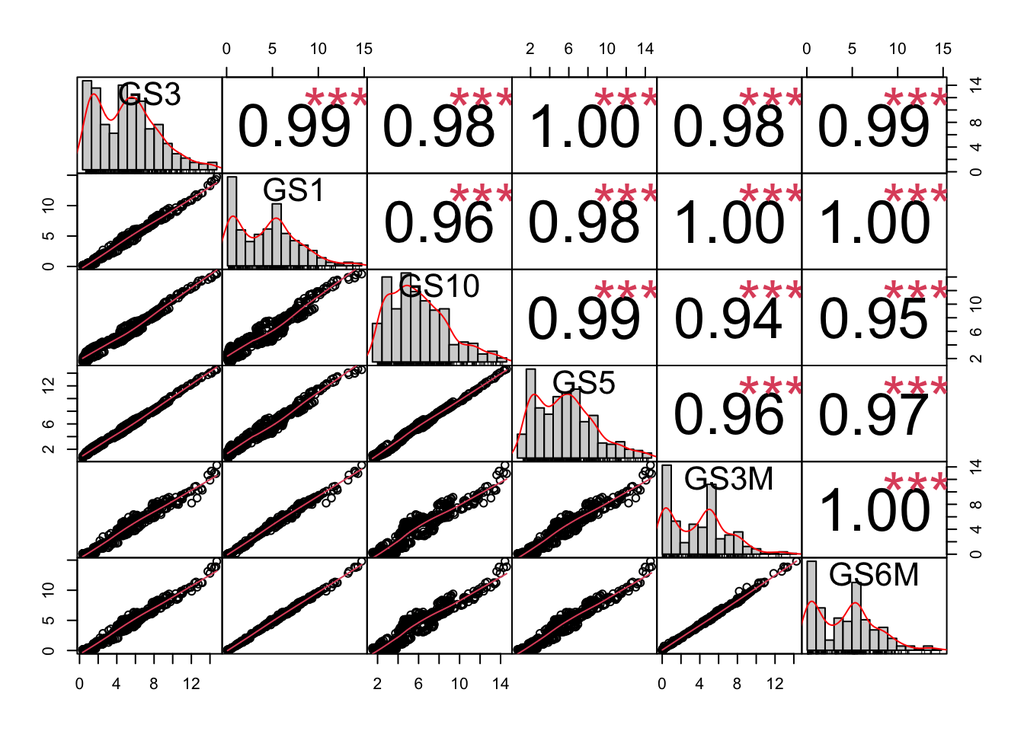

```r
PerformanceAnalytics::chart.Correlation(taxas_juros)
```

As séries das taxas de juros apresentam correlação positiva muito forte (como esperado), todas superiores a 90%. Isto posto, certamente, a magnitude das correlações observadas justificam a aplicação da Análise de Componentes Principais.

### 1.3

```r
pca_juros <- prcomp(taxas_juros, scale = TRUE)
summary(pca_juros)
```

```
Importance of components:
                          PC1     PC2     PC3     PC4     PC5      PC6
Standard deviation     2.4278 0.31481 0.07205 0.03745 0.01418 0.009422
Proportion of Variance 0.9823 0.01652 0.00087 0.00023 0.00003 0.000010
Cumulative Proportion  0.9823 0.99885 0.99972 0.99995 0.99999 1.000000
```

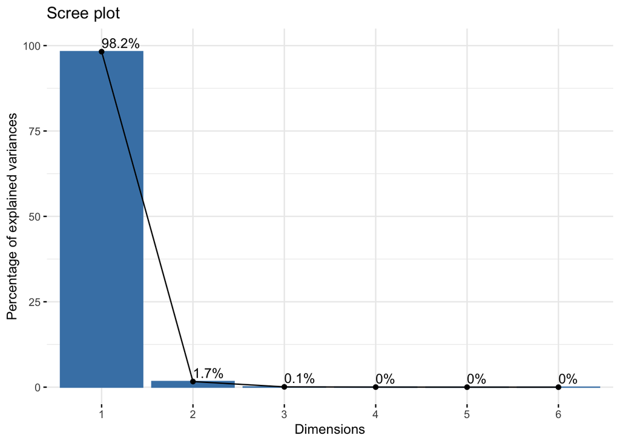

```r
factoextra::fviz_screeplot(pca_juros,
  choice = "variance", addlabels = TRUE,
  ylim = c(0, 100)
)
```

Como vimos em aula, não há uma resposta exata para esta questão, a qual depende principalmente dos objetivos da análise. Entretanto, sem informações adicionais, 2 componentes principais parecem adequados, pois capturam 99,89% da variabilidade total das séries de taxas de juros e considerando que o objetivo da PCA é reduzir a dimensão dos dados.

### 1.4

A função `?round` arredonda os resultados para o número de casas decimais utilizadas no segundo argumento, no caso, utilizaremos duas:

```r
round(pca_juros$rotation, 2)
```

```
       PC1   PC2   PC3   PC4   PC5   PC6
GS3  -0.41 -0.12 -0.54  0.29 -0.42 -0.51
GS1  -0.41  0.26 -0.34 -0.55 -0.25  0.53
GS10 -0.40 -0.64  0.51 -0.35 -0.19 -0.11
GS5  -0.41 -0.37 -0.21  0.41  0.55  0.42
GS3M -0.41  0.46  0.53  0.49 -0.28  0.17
GS6M -0.41  0.39  0.07 -0.29  0.58 -0.50
```

$$\begin{aligned}
PC1 &= -0,41(GS3) - 0,41(GS1) - 0,40(GS10) - 0,41(GS5) - 0,41(GS3M) - 0,41(GS6M)\\
PC2 &= -0,12(GS3) + 0,26(GS1) - 0,64(GS10) - 0,37(GS5) + 0,46(GS3M) + 0,39(GS6M)
\end{aligned}$$

### 1.5

As séries de taxasa de juros analisadas fornecem evidências favoráveis a esta interpretação, pois, observando os vetores de cargas dos dois primeiros componentes, verifica-se que o primeiro componente compreende cargas aproximadamente iguais para todas as seis séries, e que o segundo componente atribui cargas negativas maiores às séries com vencimento mais longos, sendo que as cargas aumentam gradualmente para as séries com vencimentos mais curtos.

## Questão 2

### 2.1

```r
# define o caminho do arquivo
path_csv <- here::here("data_raw", "HousePrices.csv")

# importa o arquivo
house_prices <- readr::read_csv(path_csv)

# visao geral da estrutura dos dados
dplyr::glimpse(house_prices)
```

```
Rows: 150
Columns: 5
$ `price in usd` <dbl> 107496, 102012, 118100, 102439, 97648, 104024, 122642, …
$ rooms          <dbl> 4.494, 4.235, 4.415, 4.526, 4.043, 4.261, 4.974, 4.508,…
$ income         <dbl> 61168, 56311, 64746, 56074, 47908, 51624, 61236, 53677,…
$ `Tax Rate`     <dbl> 1.937, 3.975, 1.557, 2.771, 4.275, 2.155, 2.274, 2.125,…
$ `%Commercial`  <dbl> 21.26, 20.22, 13.45, 20.52, 12.93, 22.82, 14.41, 22.59,…
```

Utilizando `janitor::clean_names()` para obter nomes adequados para as variáveis:

```r
house_prices <- janitor::clean_names(house_prices)
dplyr::glimpse(house_prices)
```

```
Rows: 150
Columns: 5
$ price_in_usd       <dbl> 107496, 102012, 118100, 102439, 97648, 104024, 1226…
$ rooms              <dbl> 4.494, 4.235, 4.415, 4.526, 4.043, 4.261, 4.974, 4.…
$ income             <dbl> 61168, 56311, 64746, 56074, 47908, 51624, 61236, 53…
$ tax_rate           <dbl> 1.937, 3.975, 1.557, 2.771, 4.275, 2.155, 2.274, 2.…
$ percent_commercial <dbl> 21.26, 20.22, 13.45, 20.52, 12.93, 22.82, 14.41, 22…
```

### 2.2

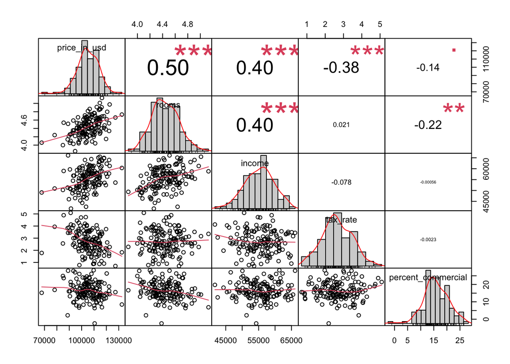

```r
PerformanceAnalytics::chart.Correlation(house_prices)
```

Inspecioando o gráfico, vê-se claramente que a variável que apresenta a menor correlação com a variável `price_in_usd` é a variável `percent_commercial` que representa a porcentagem de imóveis commerciais em cada cidade constante nos dados, sendo que o coeficiente de correlação de Pearson estimado foi $\hat{r} = -0,14 = -14\%$.

### 2.3

```r
reg1 <- lm(price_in_usd ~ rooms, data = house_prices)
reg2 <-  lm(price_in_usd ~ income, data = house_prices)
reg3 <- lm(price_in_usd ~ tax_rate, data = house_prices)
reg4 <- lm(price_in_usd ~ percent_commercial, data = house_prices)
```

Obtendo o $R^2-$adj em porcentagem:

**Importante**

Como vocês podem verificar, o comando correto para obter somente o $R^2-$adj de um objeto que contém os resultados da estimação de um modelo linear é `summary(reg1)$adj.r.squared` e não `reg1$adj.r.squared`. Isto posto, considerei este erro na correção.

```r
(summary(reg1)$adj.r.squared)*100
```

```
[1] 24.63779
```

```r
(summary(reg2)$adj.r.squared)*100
```

```
[1] 15.82317
```

```r
(summary(reg3)$adj.r.squared)*100
```

```
[1] 13.70014
```

```r
(summary(reg4)$adj.r.squared)*100
```

```
[1] 1.199437
```

```r
reg_mult <-
  lm(price_in_usd ~ rooms + income + tax_rate + percent_commercial,
     data = house_prices)
summary(reg_mult)
```

```
Call:
lm(formula = price_in_usd ~ rooms + income + tax_rate + percent_commercial,
    data = house_prices)

Residuals:
   Min     1Q Median     3Q    Max
-32241  -3881    191   4288  22422

Coefficients:
                     Estimate Std. Error t value Pr(>|t|)
(Intercept)        20083.5355 12355.8105   1.625  0.10624
rooms              16937.6420  2859.3548   5.924 2.19e-08 ***
income                 0.3910     0.1283   3.048  0.00274 **
tax_rate           -3801.8121   641.4735  -5.927 2.16e-08 ***
percent_commercial   -85.7450   116.5882  -0.735  0.46325
---
Signif. codes:  0 '***' 0.001 '**' 0.01 '*' 0.05 '.' 0.1 ' ' 1

Residual standard error: 7132 on 145 degrees of freedom
Multiple R-squared:  0.4391,    Adjusted R-squared:  0.4236
F-statistic: 28.37 on 4 and 145 DF,  p-value: < 2.2e-16
```

A estimativa do $R^2-$adj para o modelo de regressão linear múltipla estimado foi 42,36%. O $R^2-$adj é uma medida da qualidade do ajuste de um modelo de regressão linear, que assume valores entre 0 e 1 (100%), e quantifica a porcentagem da variabilidade da variável resposta `price_in_usd` explicada pelo modelo estimado, ou seja, 42,36% da variabilidade da variável resposta `price_in_usd`, é explicada por um modelo contendo as variáveis preditoras `rooms`, `income`, `tax_rate` e `percent_commercial`.

### 2.5

Não há uma única forma de escrever o modelo de regressão estimado, uma possibilidade é:

$$\widehat{\text{price_in_usd}} = 20083,54 + 16937,64(rooms) +
0,39(income) - 3801,81(\text{tax_rate})
- 85,75(\text{percent_commercial})$$

### 2.6

Utilizando o nívei usual de significância para um teste de hipóteses, $\alpha = 5% = 0,05$ e obervando o resultado de `summary(reg_mult)`, podemos concluir que os dados fornecem evidências de que os parâmetros $\hat{\beta}_{rooms}$, $\hat{\beta}_{income}$ e $\hat{\beta}_{\text{tax_rate}}$ são estatiscamente diferentes de zero, pois os valores-p do teste t da hipótese nula ($H_0: \beta_j = 0$) são menores que 0,05, isto é, é improvável obtermos as estatísticas do teste calculadas, se a hipótese nula fosse “verdadeira” em cada um dos três testes.

### 2.7

Por padrão, o nível de confiança é 95% (`level = 0.95`), escrevemos o argumento para ilustrar como definir o nível de confiança desejado:

```r
confint(reg_mult, level = 0.95)
```

```
                           2.5 %        97.5 %
(Intercept)        -4337.2243748 44504.2954268
rooms              11286.2428127 22589.0411426
income                 0.1374199     0.6445348
tax_rate           -5069.6585228 -2533.9656892
percent_commercial  -316.1768576   144.6868108
```

### 2.8

Observando o intervalo estimado para o coeficiente associado a `tax_rate`, verificamos que $ 5.000,00 está dentro do intervalo estimado, assim, não podemos rejeitar a afirmação do político local ao nível de confiança de 95% (ou ao nível de significância de 5%).

Entretanto, veja que $ 5.000,00 está bastante próximo do limite inferior do intervalo, o que aumenta a incerteza sobre a afirmativa do político.

```r
confint(reg_mult)
```

```
                           2.5 %        97.5 %
(Intercept)        -4337.2243748 44504.2954268
rooms              11286.2428127 22589.0411426
income                 0.1374199     0.6445348
tax_rate           -5069.6585228 -2533.9656892
percent_commercial  -316.1768576   144.6868108
```

Analisando o valor-p do teste, os dados fornecem evidências de que não devemos rejeitar a hipótese nula de que a redução é igual a $ 5.000,00, mas observe que rejeitaríamos a hipótese nula se fossem adotados um nível de signficância de 7% ou 10%.

```r
car::linearHypothesis(reg_mult, c("tax_rate = -5000"))
```

```
Linear hypothesis test

Hypothesis:
tax_rate = - 5000

Model 1: restricted model
Model 2: price_in_usd ~ rooms + income + tax_rate + percent_commercial

  Res.Df        RSS Df Sum of Sq      F Pr(>F)
1    146 7552472828
2    145 7375018124  1 177454704 3.4889 0.0638 .
---
Signif. codes:  0 '***' 0.001 '**' 0.01 '*' 0.05 '.' 0.1 ' ' 1
```